# 1. House price dataset. (25 points)

## (a) (10 points) Fit the Ridge regression model to predict Price from all variable.

```python
%matplotlib inline

import pandas as pd
import numpy as np
import matplotlib.pyplot as plt
from sklearn.preprocessing import scale ,StandardScaler
from sklearn.model_selection import train_test_split, GridSearchCV, RepeatedKFold, cross_val_score
from sklearn.linear_model import Ridge, RidgeCV, Lasso, LassoCV,ElasticNet
from sklearn.metrics import mean_squared_error, roc_auc_score, accuracy_score
import matplotlib
from scipy.stats import skew
from sklearn.feature_selection import SelectFromModel
from itertools import product
from IPython.core.display import display, HTML
import warnings
import scipy.io
from sklearn.tree import DecisionTreeClassifier
from sklearn.tree import plot_tree
from sklearn.metrics import f1_score
```

```python
# Importing RealEstate.csv after downloading from link
inp_data = pd.read_csv("/Users/ankurdave/OneDrive - Georgia Institute of Technology/ISYE-6740/2021/homework6/data/RealEstate.csv")
```

```python
# Dropping columns MLS and Location from Calculation
housing_data = inp_data.drop(columns= ['MLS','Location'])
```

```python
from sklearn.preprocessing import OneHotEncoder
```

```python
# Splitting Status as dummy variable one hot key
housing_data_updated = pd.get_dummies(housing_data.Status, prefix='Status')
```

```python
# Concat the dummy variable with the main dat set and remove the original column Status
hs_data = pd.concat([housing_data, housing_data_updated], axis=1)
hs_data = hs_data.drop(columns = 'Status')
hs_data
```

|  | Price | Bedrooms | Bathrooms | Size | Price/SQ.Ft | Status_Foreclosure | Status_Regular | Status_Short Sale |
| --- | --- | --- | --- | --- | --- | --- | --- | --- |
| 0 | 795000.0 | 3 | 3 | 2371 | 335.30 | 0 | 0 | 1 |
| 1 | 399000.0 | 4 | 3 | 2818 | 141.59 | 0 | 0 | 1 |
| 2 | 545000.0 | 4 | 3 | 3032 | 179.75 | 0 | 0 | 1 |
| 3 | 909000.0 | 4 | 4 | 3540 | 256.78 | 0 | 0 | 1 |
| 4 | 109900.0 | 3 | 1 | 1249 | 87.99 | 0 | 0 | 1 |
| ... | ... | ... | ... | ... | ... | ... | ... | ... |
| 776 | 319900.0 | 3 | 3 | 1605 | 199.31 | 0 | 1 | 0 |
| 777 | 495000.0 | 3 | 2 | 1877 | 263.72 | 0 | 1 | 0 |
| 778 | 372000.0 | 3 | 2 | 1104 | 336.96 | 1 | 0 | 0 |
| 779 | 589000.0 | 3 | 2 | 1975 | 298.23 | 0 | 1 | 0 |
| 780 | 1100000.0 | 3 | 3 | 2392 | 459.87 | 0 | 1 | 0 |

781 rows × 8 columns

```python
# Create X and y for running the model
X = hs_data.drop('Price', axis = 1)
y = hs_data['Price']
```

```python
print(X)
print(y)
```

```
     Bedrooms  Bathrooms  Size  Price/SQ.Ft  Status_Foreclosure  \
0           3          3  2371       335.30                   0
1           4          3  2818       141.59                   0
2           4          3  3032       179.75                   0
3           4          4  3540       256.78                   0
4           3          1  1249        87.99                   0
..        ...        ...   ...          ...                 ...
776         3          3  1605       199.31                   0
777         3          2  1877       263.72                   0
778         3          2  1104       336.96                   1
779         3          2  1975       298.23                   0
780         3          3  2392       459.87                   0

     Status_Regular  Status_Short Sale
0                 0                  1
```

[output cut: 24 more lines]

```python
#from sklearn.model_selection import train_test_split
#X_train, X_test, Y_train, Y_test = train_test_split(X, Y, test_size = 0.20, random_state = 5)
#print(X_train.shape)
#print(X_test.shape)
#print(Y_train.shape)
#print(Y_test.shape)
```

```python
# Ridge Model
model = Ridge()
#  5 - fold cross validation
cv = RepeatedKFold(n_splits=5, n_repeats=3, random_state=1)
# define grid for alpha values
grid = dict()
grid['alpha'] = arange(0, 1, 0.01)
# define search
search = GridSearchCV(model, grid, scoring ='neg_mean_absolute_error', cv=cv)
# perform the search
results = search.fit(X, y)
# summarize
print('MAE: %.3f' % results.best_score_)
print('Config: %s' % results.best_params_)
```

```
MAE: -65177.315
Config: {'alpha': 0.99}
```

```python
#alphas = 10**np.linspace(10,-2,100)*0.5
alphas = [100,10, 1, 0.1 ,0.01]
alphas
```

```
[100, 10, 1, 0.1, 0.01]
```

```python
ridge = Ridge(normalize = True)
coefs = []

for a in alphas:
    ridge.set_params(alpha = a)
    ridge.fit(X, y)
    coefs.append(ridge.coef_)

np.shape(coefs)
```

```
(5, 7)
```

```python
ridge.coef_
```

```
array([-10006.30091368,  19114.20456983,    245.26000861,   1819.45973587,
        -2198.91109667,  28716.79558686, -13053.28576906])
```

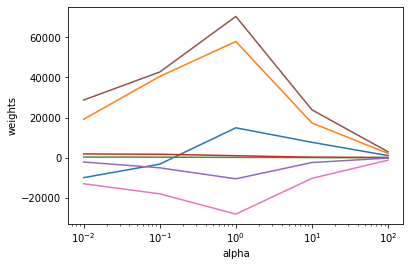

```python
ax = plt.gca()
ax.plot(alphas, coefs)
ax.set_xscale('log')
plt.axis('tight')
plt.xlabel('alpha')
plt.ylabel('weights')
```

```python
ridgecv = RidgeCV(alphas = alphas, scoring = 'neg_mean_squared_error', normalize = True)
ridgecv.fit(X, y)
ridgecv.alpha_
```

```
0.01
```

## (b) (10 points) Use lasso to select variables.

```python
# 5 fold cross validation
cv = RepeatedKFold(n_splits=5, n_repeats=3, random_state=1)
# Lasso CV model
model = LassoCV(alphas=arange(0, 1, 0.01), cv=cv, n_jobs=-1)
# fit model
model.fit(X, y)
# summarize chosen configuration
print('alpha: %f' % model.alpha_)
```

```
alpha: 0.980000
```

## (c) (5 points) Use elastic net to select variables.

```python
# 5 fold cross validation
def elastic_cv(model):
    rmse= cross_val_score(model, X, y, scoring="neg_mean_squared_error", cv = 5)
    return(rmse)
```

```python
alphas = [0.0005, 0.001, 0.01, 0.03, 0.05, 0.1]
l1_ratios = [1.5, 1.1, 1, 0.9, 0.8, 0.7, 0.5]
```

```python
cv_elasticnet = [elastic_cv(ElasticNet(alpha = alpha, l1_ratio=l1_ratio)).mean()
            for (alpha, l1_ratio) in product(alphas, l1_ratios)]
```

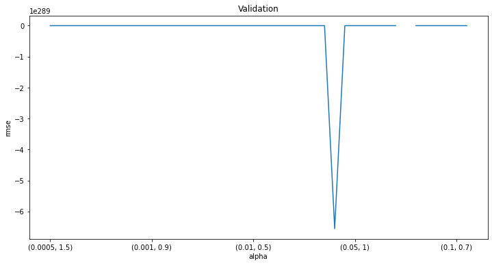

```python
matplotlib.rcParams['figure.figsize'] = (12.0, 6.0)
idx = list(product(alphas, l1_ratios))
p_cv_elastic = pd.Series(cv_elasticnet, index = idx)
p_cv_elastic.plot(title = "Validation")
plt.xlabel("alpha")
plt.ylabel("rmse")
```

```python
elastic.fit(X, y)
```

```
ElasticNet(alpha=0.0005, l1_ratio=0.9)
```

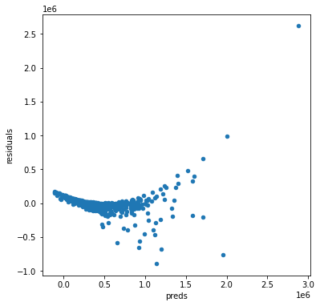

```python
#let's look at the residuals as well:
matplotlib.rcParams['figure.figsize'] = (6.0, 6.0)

preds = pd.DataFrame({"preds":elastic.predict(X), "true":y})
preds["residuals"] = preds["true"] - preds["preds"]
preds.plot(x = "preds", y = "residuals",kind = "scatter")
```

```python
rmse = np.sqrt(np.mean((preds['true']-preds['preds'])**2))
print ('RMSE: {0:.4f}'.format(rmse))
```

```
RMSE: 144373.1324
```

```python
from sklearn.metrics import r2_score
print('R^2 train: %.3f' %  r2_score(preds['true'], preds['preds']))
```

```
R^2 train: 0.829
```

```python
coef = pd.Series(elastic.coef_, index = X_train.columns)
```

```python
print("Elastic Net picked " + str(sum(coef != 0)) + " variables and eliminated the other " +  str(sum(coef == 0)) + " variables")
```

```
Elastic Net picked 7 variables and eliminated the other 0 variables
```

# 2. AdaBoost. (25 points)

## (a) (15 points) For each iteration t = 1, 2, 3, compute εt, αt, Zt, Dt by hand (i.e., show the calculation steps) and draw the decision stumps on the figure (you can draw this by hand).

```python
X_1 = (-1, 0, '+')
X_2 = (-0.5, 0.5, '+')
X_3 = (0, 1, '-')
X_4 = (0.5, 1, '-')
X_5 = (1, 0, '+')
X_6 = (1, -1, '+')
X_7 = (0, -1, '-')
X_8 = (0, 0, '-')
```

```python
points = [X_1,X_2,X_3,X_4,X_5,X_6,X_7,X_8]
hor_plus = [x for x,y,m in points if m=='+']
hor_minus = [x for x,y,m in points if m=='-']
ver_plus = [y for x,y,m in points if m=='+']
ver_minus = [y for x,y,m in points if m=='-']
markers = [m for x,y,m in points]
points
```

```
[(-1, 0, '+'),
 (-0.5, 0.5, '+'),
 (0, 1, '-'),
 (0.5, 1, '-'),
 (1, 0, '+'),
 (1, -1, '+'),
 (0, -1, '-'),
 (0, 0, '-')]
```

```python
X = np.array([(x,y) for x,y,m in points])
X
```

```
array([[-1. ,  0. ],
       [-0.5,  0.5],
       [ 0. ,  1. ],
       [ 0.5,  1. ],
       [ 1. ,  0. ],
       [ 1. , -1. ],
       [ 0. , -1. ],
       [ 0. ,  0. ]])
```

```python
y = np.array([1 if m=='+' else -1 if m=='-' else None for m in [m for x,y,m in points]])
y
```

```
array([ 1,  1, -1, -1,  1,  1, -1, -1])
```

```python
def weak_learn_1(x_1,x_2):
    return 1 if x_1<-0.25 else -1 if x_1>-0.25 else None
weak_learn_1 = np.vectorize(weak_learn_1)
pred_1 = weak_learn_1(X[:,0],X[:,1])
m=X.shape[0]
D_1 = np.ones(m)*1/m
error_1 = (D_1 * (pred_1!=y)).sum()
a_1 = 1/2*np.log((1-error_1)/error_1)
D_2_unnormalized = D_1*np.exp(-a_1*y*pred_1)
Z_1 = D_2_unnormalized.sum()
D_2 = D_2_unnormalized/Z_1
D_2.sum()==1
iter_1 = [error_1, a_1, Z_1] + list(D_1)
display(pd.DataFrame(np.array([1]+iter_1).reshape(1,-1), columns=['Iteration','e_t','a_t','Z_t','D_t_1','D_t_2','D_t_3','D_t_4','D_t_5','D_t_6','D_t_7','D_t_8']))
```

|  | Iteration | e_t | a_t | Z_t | D_t_1 | D_t_2 | D_t_3 | D_t_4 | D_t_5 | D_t_6 | D_t_7 | D_t_8 |
| --- | --- | --- | --- | --- | --- | --- | --- | --- | --- | --- | --- | --- |
| 0 | 1.0 | 0.25 | 0.549306 | 0.866025 | 0.125 | 0.125 | 0.125 | 0.125 | 0.125 | 0.125 | 0.125 | 0.125 |

```python
def weak_learn_2(x_1,x_2):
    return 1 if x_1>0.75 else -1 if x_1<0.75 else None
weak_learn_2 = np.vectorize(weak_learn_2)
pred_2 = weak_learn_2(X[:,0],X[:,1])
error_2 = (D_2 * (pred_2!=y)).sum()
a_2 = 1/2*np.log((1-error_2)/error_2)
D_3_unnormalized = D_2*np.exp(-a_2*y*pred_2)
Z_2 = D_3_unnormalized.sum()
D_3 = D_3_unnormalized/Z_2
np.round(D_3.sum(),8) == 1
iter_2 = [error_2, a_2, Z_2] + list(D_2)
display(pd.DataFrame(np.array([2]+iter_2).reshape(1,-1), columns=['Iteration','e_t','a_t','Z_t','D_t_1','D_t_2','D_t_3','D_t_4','D_t_5','D_t_6','D_t_7','D_t_8']))
```

|  | Iteration | e_t | a_t | Z_t | D_t_1 | D_t_2 | D_t_3 | D_t_4 | D_t_5 | D_t_6 | D_t_7 | D_t_8 |
| --- | --- | --- | --- | --- | --- | --- | --- | --- | --- | --- | --- | --- |
| 0 | 2.0 | 0.166667 | 0.804719 | 0.745356 | 0.083333 | 0.083333 | 0.083333 | 0.083333 | 0.25 | 0.25 | 0.083333 | 0.083333 |

```python
def weak_learn_3(x_1,x_2):
    return -1 if x_2>0.75 else 1 if x_2<0.75 else None
weak_learn_3 = np.vectorize(weak_learn_3)
pred_3 = weak_learn_3(X[:,0],X[:,1])
error_3 = (D_3 * (pred_3!=y)).sum()
a_3 = 1/2*np.log((1-error_3)/error_3)
D_4_unnormalized = D_3*np.exp(-a_3*y*pred_3)
Z_3 = D_4_unnormalized.sum()
iter_3 = [error_3, a_3, Z_3] + list(D_3)
display(pd.DataFrame(np.array([3]+iter_3).reshape(1,-1), columns=['Iteration','e_t','a_t','Z_t','D_t_1','D_t_2','D_t_3','D_t_4','D_t_5','D_t_6','D_t_7','D_t_8']))
```

|  | Iteration | e_t | a_t | Z_t | D_t_1 | D_t_2 | D_t_3 | D_t_4 | D_t_5 | D_t_6 | D_t_7 | D_t_8 |
| --- | --- | --- | --- | --- | --- | --- | --- | --- | --- | --- | --- | --- |
| 0 | 3.0 | 0.1 | 1.098612 | 0.6 | 0.25 | 0.25 | 0.05 | 0.05 | 0.15 | 0.15 | 0.05 | 0.05 |

```python
# Displaying the e, Z and D values for the three Weak learners.
Table = pd.DataFrame([iter_1, iter_2, iter_3], columns=['e_t','a_t','Z_t','D_t_1','D_t_2','D_t_3','D_t_4','D_t_5','D_t_6','D_t_7','D_t_8'], index=[1,2,3])
display(Table)
```

|  | e_t | a_t | Z_t | D_t_1 | D_t_2 | D_t_3 | D_t_4 | D_t_5 | D_t_6 | D_t_7 | D_t_8 |
| --- | --- | --- | --- | --- | --- | --- | --- | --- | --- | --- | --- |
| 1 | 0.250000 | 0.549306 | 0.866025 | 0.125000 | 0.125000 | 0.125000 | 0.125000 | 0.125 | 0.125 | 0.125000 | 0.125000 |
| 2 | 0.166667 | 0.804719 | 0.745356 | 0.083333 | 0.083333 | 0.083333 | 0.083333 | 0.250 | 0.250 | 0.083333 | 0.083333 |
| 3 | 0.100000 | 1.098612 | 0.600000 | 0.250000 | 0.250000 | 0.050000 | 0.050000 | 0.150 | 0.150 | 0.050000 | 0.050000 |

## (b) (10 points) What is the training error of this AdaBoost? Give a short explanation for why AdaBoost outperforms a single decision stump.

```python
def final_ada_boost(x_1,x_2):
    return np.sign(a_1*first_weak_learner(x_1,x_2) + a_2*second_weak_learner(x_1,x_2) + a_3*third_weak_learner(x_1,x_2))
```

```python
final_pred = final_ada_boost(X[:,0],X[:,1])
final_pred
accuracy_score(y,final_pred)
```

```
1.0
```

```python
x1,x2 = np.meshgrid(np.arange(X[:,0].min()-0.5, X[:,0].max()+0.5, 0.01), np.arange(X[:,1].min()-0.5,X[:,1].max()+0.5,0.01))
```

```python
mesh_pred = final_ada_boost(x1.ravel(),x2.ravel()).reshape(x1.shape)
```

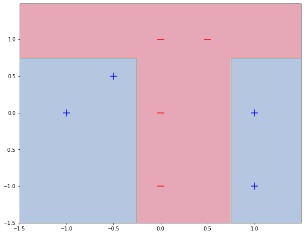

```python
plt.figure(figsize=(10,8))
plt.contourf(x1,x2,mesh_pred,cmap='Spectral', alpha=0.4)
plt.scatter(x=X[final_pred==1,0],y=X[final_pred==1,1],marker='+',s=200, c='blue')
plt.scatter(x=X[final_pred==-1,0],y=X[final_pred==-1,1],marker='_',s=200,c='red');
```

```python
print(f'Accuracy score: {accuracy_score(y,final_pred)}')
```

```
Accuracy score: 1.0
```

### The accuracy of the AdaBoost Classifier here is 100%, the training error is 0. AdaBoost outperforms a single decision stump because it is an ensemble of shallow learners combined sequentially with each subsequent classifier correcting the errors of the previous ones, and with the weights adjusting in a way that more emphasis is placed on previously misclasified datapoints, thus continually improving the accuracy with each iteration.

# 3. Random forest and one-class SVM for email spam classifier (25 points)

## (a) (5 points) Build a CART model and visualize the fitted classification tree.

```python
# Importing data
data_email = pd.read_csv("/Users/ankurdave/OneDrive - Georgia Institute of Technology/ISYE-6740/2021/homework6/data/spambase.data", header=None)
data_email
```

|  | 0 | 1 | 2 | 3 | 4 | 5 | 6 | 7 | 8 | 9 | ... | 48 | 49 | 50 | 51 | 52 | 53 | 54 | 55 | 56 | 57 |
| --- | --- | --- | --- | --- | --- | --- | --- | --- | --- | --- | --- | --- | --- | --- | --- | --- | --- | --- | --- | --- | --- |
| 0 | 0.00 | 0.64 | 0.64 | 0.0 | 0.32 | 0.00 | 0.00 | 0.00 | 0.00 | 0.00 | ... | 0.000 | 0.000 | 0.0 | 0.778 | 0.000 | 0.000 | 3.756 | 61 | 278 | 1 |
| 1 | 0.21 | 0.28 | 0.50 | 0.0 | 0.14 | 0.28 | 0.21 | 0.07 | 0.00 | 0.94 | ... | 0.000 | 0.132 | 0.0 | 0.372 | 0.180 | 0.048 | 5.114 | 101 | 1028 | 1 |
| 2 | 0.06 | 0.00 | 0.71 | 0.0 | 1.23 | 0.19 | 0.19 | 0.12 | 0.64 | 0.25 | ... | 0.010 | 0.143 | 0.0 | 0.276 | 0.184 | 0.010 | 9.821 | 485 | 2259 | 1 |
| 3 | 0.00 | 0.00 | 0.00 | 0.0 | 0.63 | 0.00 | 0.31 | 0.63 | 0.31 | 0.63 | ... | 0.000 | 0.137 | 0.0 | 0.137 | 0.000 | 0.000 | 3.537 | 40 | 191 | 1 |
| 4 | 0.00 | 0.00 | 0.00 | 0.0 | 0.63 | 0.00 | 0.31 | 0.63 | 0.31 | 0.63 | ... | 0.000 | 0.135 | 0.0 | 0.135 | 0.000 | 0.000 | 3.537 | 40 | 191 | 1 |
| ... | ... | ... | ... | ... | ... | ... | ... | ... | ... | ... | ... | ... | ... | ... | ... | ... | ... | ... | ... | ... | ... |
| 4596 | 0.31 | 0.00 | 0.62 | 0.0 | 0.00 | 0.31 | 0.00 | 0.00 | 0.00 | 0.00 | ... | 0.000 | 0.232 | 0.0 | 0.000 | 0.000 | 0.000 | 1.142 | 3 | 88 | 0 |
| 4597 | 0.00 | 0.00 | 0.00 | 0.0 | 0.00 | 0.00 | 0.00 | 0.00 | 0.00 | 0.00 | ... | 0.000 | 0.000 | 0.0 | 0.353 | 0.000 | 0.000 | 1.555 | 4 | 14 | 0 |
| 4598 | 0.30 | 0.00 | 0.30 | 0.0 | 0.00 | 0.00 | 0.00 | 0.00 | 0.00 | 0.00 | ... | 0.102 | 0.718 | 0.0 | 0.000 | 0.000 | 0.000 | 1.404 | 6 | 118 | 0 |
| 4599 | 0.96 | 0.00 | 0.00 | 0.0 | 0.32 | 0.00 | 0.00 | 0.00 | 0.00 | 0.00 | ... | 0.000 | 0.057 | 0.0 | 0.000 | 0.000 | 0.000 | 1.147 | 5 | 78 | 0 |
| 4600 | 0.00 | 0.00 | 0.65 | 0.0 | 0.00 | 0.00 | 0.00 | 0.00 | 0.00 | 0.00 | ... | 0.000 | 0.000 | 0.0 | 0.125 | 0.000 | 0.000 | 1.250 | 5 | 40 | 0 |

4601 rows × 58 columns

```python
# Populating X and y for running model
X = email.iloc[:,:-1]
y = email.iloc[:,-1]
```

```python
# Splitting the train test data 80-20
X_train, X_test, y_train, y_test = train_test_split(X, y, train_size=0.8,test_size=0.2)
```

```python
dt_class = DecisionTreeClassifier(criterion='entropy',max_depth=4,min_samples_leaf=50)
```

```python
dt_class.fit(X_train, y_train)
```

```
DecisionTreeClassifier(criterion='entropy', max_depth=4, min_samples_leaf=50)
```

```python
# Actual class predictions
dt_predictions = dt_class.predict(X_test)
# Probabilities for each class
dt_probs = dt_class.predict_proba(X_test)[:, 1]
```

```python
# Calculate roc auc
roc_value_dt = roc_auc_score(y_test, dt_probs)
roc_value_dt
```

```
0.9371731645117438
```

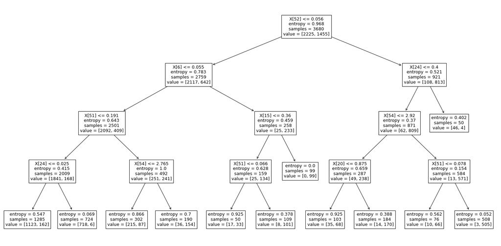

```python
plt.figure(figsize=(26,13))
plot_tree(dt_class);
```

## (b) (10 points) Now also build a random forest model.

```python
from sklearn.ensemble import RandomForestClassifier
```

```python
model = RandomForestClassifier(n_estimators=100, bootstrap = True,max_features = 'sqrt')
# Fit on training data
model.fit(X_train, y_train)
```

```
RandomForestClassifier(max_features='sqrt')
```

```python
# Actual class predictions
rf_predictions = model.predict(X_test)
# Probabilities for each class
rf_probs = model.predict_proba(X_test)[:, 1]
```

```python
# Calculate roc auc
roc_value = roc_auc_score(y_test, rf_probs)
roc_value
```

```
0.9850858826914872
```

## (c) (10 points) Now we will use a one-class SVM approach for spam filtering.

```python
from sklearn.svm import SVC
svm_class = SVC(kernel = 'rbf', random_state = 0)
svm_class.fit(X_train, y_train)
```

```
SVC(random_state=0)
```

```python
print(svm_class.score(X_test,y_test))
```

```
0.7274701411509229
```

# 4. Locally weighted linear regression and bias-variance tradeoff. (25 points)

parameter in the maximum likelihood estimate of β can be written as follows βˆ(λ) = arg min (Xβ − y)T W (Xβ − y) + λ∥β∥2

$$\hat \beta(\lambda) = \arg\min_{\beta}\left\{\frac 1 n \sum_{i=1}^n (y_i -x_i^T \beta)^2 + \lambda \|\beta\|_2^2\right\}$$

## (b) (5 points) Find the close-form solution for β(λ) and its distribution conditioning on {xi}.

For inimizing the beta function, taking the derivative of $\hat\beta(\lambda)$ with respect to $\beta$ and setting it equal to zero. Then we solve for $\hat\beta$:

$$\frac{\partial{\hat \beta(\lambda)}}{\partial{\beta}} = \arg\min_{\beta}\left\{-\frac{2}{n}Xy + \frac{2}{m}XX^T\beta + \frac{2\lambda}{m}\beta\right\} = \arg\min_{\beta}\left\{-2X^T(y - \beta^TX) + 2\lambda\beta\right\} = 0$$

Step2 will be solving the equation for $\hat\beta$:

$$\hat\beta(\lambda) = (X^TX + \lambda I)^{-1} X^T y$$

with $y$ is the random variable.

$$\mathbb E[\hat\beta] = (X^TX + \lambda I)^{-1} X^T X \beta^*$$

Here $\beta^*$ denotes the real parameters.

$$Var[\hat\beta] = \sigma^2 (X^TX + \lambda I)^{-1} X^T X [(X^TX + \lambda I)^{-1}]^T$$

The random variable $y$ is Gaussian, since the error term $\epsilon$ is Gaussian. Then consequently $\hat\beta$ is Gaussian. So:

$$\hat\beta \sim \mathcal{N}(\mathbb E[\hat\beta],Var[\hat\beta]) $$

## (c) (5 points) Derive the bias as a function of λ and some fixed test point x.

For deriving the bias as a function of λ we take the Expectation fro the above equation as below: $$Bias = \mathbb E[x^T {\hat \beta}(\lambda)] - x^T {\beta^*} = \mathbb E[x^T {(X^TX + \lambda I)^{-1} X^T y}] - x^T {\beta^*}$$ Based on probability theory, for the random variable y and for any $\alpha$, the following is true:$$\mathbb E[\alpha y] = \alpha\mathbb E[y] = \alpha X \beta^*$$Thus the equation above becomes:

$$x^T \mathbb E[{(X^TX + \lambda I)^{-1} X^T y}] - x^T {\beta^*} = x^T {(X^TX + \lambda I)^{-1} X^T X {\beta^*}} - x^T {\beta^*}$$

So based on the above questions the Bias will be equal to : $$x^T {(X^TX + \lambda I)^{-1} X^T X {\beta^*}} - x^T {\beta^*}$$

## (d) (5 points) Derive the variance term as a function of λ.

In a previous step we calculated the $Var[\hat\beta]$. Substituting the variance in the equation we get :

$$Var[x^T\hat\beta] = x^T Var[\hat\beta] x= x^T \sigma^2 (X^TX + \lambda I)^{-1} X^T X [(X^TX + \lambda I)^{-1}]^T x$$

So variance will be $$x^T \sigma^2 (X^TX + \lambda I)^{-1} X^T X [(X^TX + \lambda I)^{-1}]^T x$$

# 5. Medical imaging reconstruction. (10 points)

```python
from PIL import Image
from scipy.fftpack import dct, idct
from sklearn.linear_model import Lasso
```

```python
# Loading image in grayscale and obtaining its dimensions
import scipy.io
img_mat = scipy.io.loadmat('/Users/ankurdave/OneDrive - Georgia Institute of Technology/ISYE-6740/2021/homework6/data/cs.mat')
img_mat
```

```
{'__header__': b'MATLAB 5.0 MAT-file, Platform: MACI64, Created on: Thu Apr  2 12:55:00 2015',
 '__version__': '1.0',
 '__globals__': [],
 'img': array([[0, 0, 0, ..., 0, 0, 0],
        [0, 0, 0, ..., 0, 0, 0],
        [0, 0, 0, ..., 0, 0, 0],
        ...,
        [0, 0, 0, ..., 0, 0, 0],
        [0, 0, 0, ..., 0, 0, 0],
        [0, 0, 0, ..., 0, 0, 0]], dtype=uint32)}
```

```python
iso_image = img_mat['img'].T
print(f'iso_image Array Shape : {iso_image.shape}.')
```

```
iso_image Array Shape : (50, 50).
```

x Select λ using 10-fold cross-validation. Plot the cross-validation error curves, and show the recov- ered image. Which approaches give a better recovered image?